# UCB algorithms

Jan Sviták, Rob van der Noll

January 28, 2020

In this notebook we present the UCB1-tuned algorithm (Auer et al, 2002) and results from the simulations using this algorithm.

The UCB (Upper confidence bound) algorithms are typical solutions to multi-armed bandit problems. They observe own choices and earned reward and learn to identify the best option.

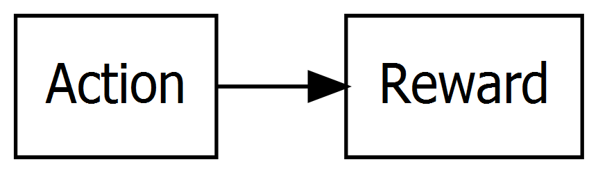

As we can see, $Q_p$ is based on the average profits for the price $p$ plus an exploration bonus. The exploration bonus leads the algorithm to experiment with arms with high variance in profits.

We first define a function carrying out the choice of the price. It calculates the above index and chooses the price with the highest value.

```r
#inputs for the function are:
#   sum of profits for each arm (pi_sum),
#   sum of squared profits for each arm (pi_sq_sum),
#   number of times each arm has been pulled (Np),
#   current period (t)
pull_arm <- function(pi_sum, pi_sq_sum, Np, t){
  #average squared profit
  pi_sq_bar <- pi_sq_sum/Np
  #average profit
  pi_bar <- pi_sum/Np
  #exploration bonus V
  V <- pi_sq_bar - pi_bar^2 + 2*log(t)/Np
  #quality index
  Q <- pi_bar + sqrt(log(t)/Np*pmin(0.25, V))
  #ties broken by random sampling
  if(length(which.max(Q)) > 1){
    sample(which.max(Q), 1)
  }
  #otherwise, arm with highest Q pulled
  else{
    which.max(Q)
  }
}
```

Next we define the function running the experiment

```r
#inputs of the function are:
#   vector of available prices (P),
#   the intercept of the logit model (alpha)
#   the price sensitivity parameter of the logit model (beta)
#   number of iterations in one experiment (N)
#   number of experiments (MC)
simulate <- function(P, alpha, beta, N, MC){
  #collect prices
  prices1 <- matrix(rep(NA, N*MC), N, MC)
  prices2 <- matrix(rep(NA, N*MC), N, MC)
  #collect profits
  profits1 <- matrix(rep(NA, N*MC), N, MC)
  profits2 <- matrix(rep(NA, N*MC), N, MC)
  #loop over experiments
  for (mc in 1:MC){
    #sum of rewards
    sum_rewards1 <- matrix(rep(0, length(P)))
    sum_rewards2 <- matrix(rep(0, length(P)))
    #sum of squared rewards
    sum_rewards_sq1 <- matrix(rep(0, length(P)))
    sum_rewards_sq2 <- matrix(rep(0, length(P)))
    #number of times each armed pulled
    Np1 <- matrix(rep(0, length(P)))
    Np2 <- matrix(rep(0, length(P)))
    #initialise (each price selected once, random order)
    pull1 <- sample(P, length(P))
    pull2 <- sample(P, length(P))
    for (t in 1:length(P)){
      #calculate profit
      reward1 <- pull1[t]*exp(alpha - beta * pull1[t])/
        (1 + exp(alpha - beta * pull1[t]) + exp(alpha - beta * pull2[t]))
      reward2 <- pull2[t]*exp(alpha - beta * pull2[t])/
        (1 + exp(alpha - beta * pull1[t]) + exp(alpha - beta * pull2[t]))
      #sum of rewards
      sum_rewards1[P == pull1[t]] <- sum_rewards1[P == pull1[t]] + reward1
      sum_rewards2[P == pull2[t]] <- sum_rewards2[P == pull2[t]] + reward2
      #sum of squared rewards
      sum_rewards_sq1[P == pull1[t]] <- sum_rewards_sq1[P == pull1[t]] + reward1^2
      sum_rewards_sq2[P == pull2[t]] <- sum_rewards_sq2[P == pull2[t]] + reward2^2
      #number of times each armed pulled
      Np1[P == pull1[t]] <- Np1[P == pull1[t]] + 1
      Np2[P == pull2[t]] <- Np2[P == pull2[t]] + 1
    }
    #loop over periods
    for (t in 1:N){
      #choose prices based on the UCB-index
      pull1 <- P[pull_arm(sum_rewards1, sum_rewards_sq1, Np1, t + length(P))]
      pull2 <- P[pull_arm(sum_rewards2, sum_rewards_sq2, Np2, t + length(P))]
      #calculate profit
      reward1 <- pull1*exp(alpha - beta * pull1)/(1 + exp(alpha - beta * pull1) + exp(alpha - beta * pull2))
      reward2 <- pull2*exp(alpha - beta * pull2)/(1 + exp(alpha - beta * pull1) + exp(alpha - beta * pull2))
      #sum of rewards
      sum_rewards1[P == pull1] <- sum_rewards1[P == pull1] + reward1
      sum_rewards2[P == pull2] <- sum_rewards2[P == pull2] + reward2
      #sum of squared rewards
      sum_rewards_sq1[P == pull1] <- sum_rewards_sq1[P == pull1] + reward1^2
      sum_rewards_sq2[P == pull2] <- sum_rewards_sq2[P == pull2] + reward2^2
      #number of times each armed pulled
      Np1[P == pull1] <- Np1[P == pull1] + 1
      Np2[P == pull2] <- Np2[P == pull2] + 1
      #collect prices
      prices1[t, mc] <- pull1
      prices2[t, mc] <- pull2
      #collect profits
      profits1[t, mc] <- reward1
      profits2[t, mc] <- reward2
    }
  }
  #save prices and profits in the environment
  prices1 <<- prices1
  prices2 <<- prices2
  profits1 <<- profits1
  profits2 <<- profits2
}
```

We let the firms choose from 10 prices between 0.1 and 1.

```r
#available prices
P <- seq(0.1, 1, 0.1)
```

We set $\alpha=\beta=5$ and run 1000 experiments with 10000 periods each.

```r
simulate(P = P, alpha = 5, beta = 5, N = 10000, MC = 1000)
```

We summarize the results from the simulation using the following figure. The left panel depicts the development of mean price across experiments and 10 and 90 percentiles. The right panel shows the histogram of all prices in the simulation pooled from all periods and experiments.

```r
plot_sim <- function(prices1, prices2, P){
  #collects prices for both firms
  PP <- data.frame(price1 = c(prices1), price2 = c(prices2))
  #wide to long forma (experiments not separate columns anymore)
  PP <- PP %>%
    gather(price1, price2, key = "firm", value = "price")
  #add iteration number
  PP$iter <- rep(1:nrow(prices1), 2*ncol(prices1))

  #calculate mean and the quantiles
  PPP <- PP %>% group_by(firm, iter) %>%
    summarize(mean = mean(price),
              upper = quantile(price, 0.9),
              lower = quantile(price, 0.1))
  PPP$type <- "Gemiddelde"
  PPP$type[(nrow(prices1)/2 + 1):nrow(prices1)] <- "10/90% kwantielen"

  #calculate frequency share for the histogram
  PP <- PP %>% group_by(firm, price) %>%
    summarize(share = length(iter)/(nrow(prices1)*ncol(prices1)))
  #left panel
  g1 <<- ggplot() +
    #mean prices
    geom_line(data = PPP, aes(x = iter, y = mean, color = firm)) +
    #90-percent quantile smoothed to prevent jumps
    geom_smooth(data = PPP, aes(x = iter, y = upper, color = firm),
                method = "loess", span = 0.1, lty = 2, se = FALSE) +
    #10-percent quantile smoothed to prevent jumps
    geom_smooth(data = PPP, aes(x = iter, y = lower, color = firm),
                method = "loess", span = 0.1, lty = 2, se = FALSE) +
    #add invisible line to create legend based on linetype
    geom_line(data = PPP, aes(x = iter, y = lower, lty = type), color = NA) +
    #choose color scale and labels
    scale_color_hue(name = "Prijszetter", labels = c("Bedrijf 1", "Bedrijf 2")) +
    #choose linetype scale labels
    scale_linetype_manual(name = "", values = c(1, 2),
                          labels = c("Gemiddelde", "10/90% kwantielen (gladgemaakt)")) +
    #choose ticks on the y-axis
    scale_y_continuous(
      breaks = seq(min(P), max(P), 0.1),
      limits = c(min(P), max(P))
    ) +
    #add horizontal line for the collusive price
    geom_hline(aes(yintercept = 0.9), color = "red", lty = 2) +
    #add horizontal line for the Nash-Bertrand price
    geom_hline(aes(yintercept = 0.4), color = "green", lty = 2) +
    #adjust legend
    guides(
      #color first, squares
      color = guide_legend(
        override.aes = list(size = 7, shape = 15),
        order = 1
      ),
      #adjust keywidth, color and size for linetype
      linetype = guide_legend(
        override.aes = list(color = "black", size = 1),
        keywidth = 3
      )
    ) +
    #black and white theme
    theme_bw() +
    #adjust some additioal theme
    theme(
      legend.key = element_blank(), #no key background
      legend.position = "bottom", #legend under figure
      legend.box = "horizontal", #color and linetype next to each other
      legend.direction = "vertical" #keys below each other
    ) +
    #adjust titles
    labs(
      y = "Prijs",
      x = "Periode",
      title = "Prijsontwikkeling"
    )

  #right panel
  g2 <<- ggplot(PP) +
    #histogram
    geom_bar(aes(x = price, y = share, fill = firm), position = "dodge", stat = "identity") +
    #bar for each price
    scale_x_continuous(
      breaks = seq(min(P), max(P), 0.1)
    ) +
    #vertical line for collusive price
    geom_vline(aes(xintercept = 0.9), color = "red", lty = 2) +
    #vertical line for Nash-Bertrand price
    geom_vline(aes(xintercept = 0.4), color = "green", lty = 2) +
    #adjust titles
    labs(
      y = "Aandeel waarnemingen",
      x = "Prijs",
      title = "Histogram prijzen"
    ) +
    #black and white theme
    theme_bw()
}
#save function
save(plot_sim, file = "plot.RData")
```

```r
#generate panels
plot_sim(prices1, prices2, P)
#construct left panel
tmp <- ggplot_gtable(ggplot_build(g1))
#identify element containing legend
leg <- which(sapply(tmp$grobs, function(x) x$name) == "guide-box")
#extract legend
legend <- tmp$grobs[[leg]]
```

```r
#arrange left and right panel with common legend underneath
png(filename = "Fig5.png", width = 1200, height = 650, pointsize = 12, res = 150)
grid.arrange(arrangeGrob(g1 + theme(legend.position = "none"),
                         g2 + theme(legend.position = "none"), nrow = 1),
             legend, nrow = 2, heights = c(10, 2))
dev.off()
```

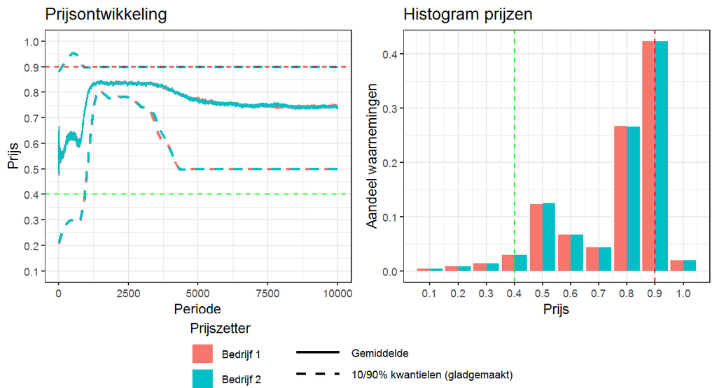

We can see that the algorithms converge to prices close to the optimal collusive outcomes in a significant number of cases. It is remarkable that without any knowledge about the environment the firms are able to coordinate on theoretically optimal outcomes.

Next, we run an analogical simulation with a limited set of prices, namely 0.3, 0.4 (Nash) and 0.5. This simulation test whether a limited choice set leads to a fast converge to a higher price (as we expect).

```r
simulate(P = c(0.3, 0.4, 0.5), alpha = 5, beta = 5, N = 10000, MC = 1000)
```

```r
plot_sim_small <- function(prices1, prices2, P){
  #collects prices for both firms
  PP <- data.frame(price1 = c(prices1), price2 = c(prices2))
  #wide to long forma (experiments not separate columns anymore)
  PP <- PP %>%
    gather(price1, price2, key = "firm", value = "price")
  #add iteration number
  PP$iter <- rep(1:nrow(prices1), 2*ncol(prices1))

  #calculate mean and the quantiles
  PPP <- PP %>% group_by(firm, iter) %>%
    summarize(mean = mean(price),
              upper = quantile(price, 0.9),
              lower = quantile(price, 0.1))
  PPP$type <- "Gemiddelde"
  PPP$type[(nrow(prices1)/2 + 1):nrow(prices1)] <- "10/90% kwantielen"

  #calculate frequency share for the histogram
  PP <- PP %>% group_by(firm, price) %>%
    summarize(share = length(iter)/(nrow(prices1)*ncol(prices1)))
  #left panel
  g1 <<- ggplot() +
    #mean prices smoothed to prevent jumps (only 3 prices)
    geom_smooth(data = PPP, aes(x = iter, y = mean, color = firm),
                method = "loess", span = 0.1, se = FALSE) +
    #90-percent quantile smoothed to prevent jumps
    geom_smooth(data = PPP, aes(x = iter, y = upper, color = firm),
                method = "loess", span = 0.1, lty = 2, se = FALSE) +
    #10-percent quantile smoothed to prevent jumps
    geom_smooth(data = PPP, aes(x = iter, y = lower, color = firm),
                method = "loess", span = 0.1, lty = 2, se = FALSE) +
    #add invisible line to create legend based on linetype
    geom_line(data = PPP, aes(x = iter, y = lower, lty = type), color = NA) +
    #choose color scale and labels
    scale_color_hue(name = "Prijszetter", labels = c("Bedrijf 1", "Bedrijf 2")) +
    #choose linetype scale labels
    scale_linetype_manual(name = "", values = c(1, 2),
                          labels = c("Gemiddelde (gladgemaakt)", "10/90% kwantielen (gladgemaakt)")) +
    #choose ticks on the y-axis
    scale_y_continuous(
      breaks = seq(min(P), max(P), 0.1),
      limits = c(min(P), max(P))
    ) +
    #add horizontal line for the Nash-Bertrand price
    geom_hline(aes(yintercept = 0.4), color = "green", lty = 2) +
    #adjust legend
    guides(
      #color first, squares
      color = guide_legend(
        override.aes = list(size = 7, shape = 15),
        order = 1
      ),
      #adjust keywidth, color and size for linetype
      linetype = guide_legend(
        override.aes = list(color = "black", size = 1),
        keywidth = 3
      )
    ) +
    #black and white theme
    theme_bw() +
    #adjust some additioal theme
    theme(
      legend.key = element_blank(), #no key background
      legend.position = "bottom", #legend under figure
      legend.box = "horizontal", #color and linetype next to each other
      legend.direction = "vertical" #keys below each other
    ) +
    #adjust titles
    labs(
      y = "Prijs",
      x = "Periode",
      title = "Prijsontwikkeling"
    )

  #right panel
  g2 <<- ggplot(PP) +
    #histogram
    geom_bar(aes(x = price, y = share, fill = firm), position = "dodge", stat = "identity") +
    #bar for each price
    scale_x_continuous(
      breaks = seq(min(P), max(P), 0.1)
    ) +
    #vertical line for Nash-Bertrand price
    geom_vline(aes(xintercept = 0.4), color = "green", lty = 2) +
    #adjust titles
    labs(
      y = "Aandeel waarnemingen",
      x = "Prijs",
      title = "Histogram prijzen"
    ) +
    #black and white theme
    theme_bw()
}
#save function
save(plot_sim, plot_sim_small, file = "plot.RData")
```

```r
#generate panels
plot_sim_small(prices1, prices2, c(0.3, 0.4, 0.5))

#construct left panel
tmp <- ggplot_gtable(ggplot_build(g1))
#identify element containing legend
leg <- which(sapply(tmp$grobs, function(x) x$name) == "guide-box")
#extract legend
legend <- tmp$grobs[[leg]]
```

```r
png(filename = "Fig_extra1.png", width = 1200, height = 650, pointsize = 12, res = 150)
#arrange left and right panel with common legend underneath
grid.arrange(arrangeGrob(g1 + theme(legend.position="none"),
                         g2 + theme(legend.position="none"), nrow = 1),
             legend, nrow=2, heights=c(10, 2))
```

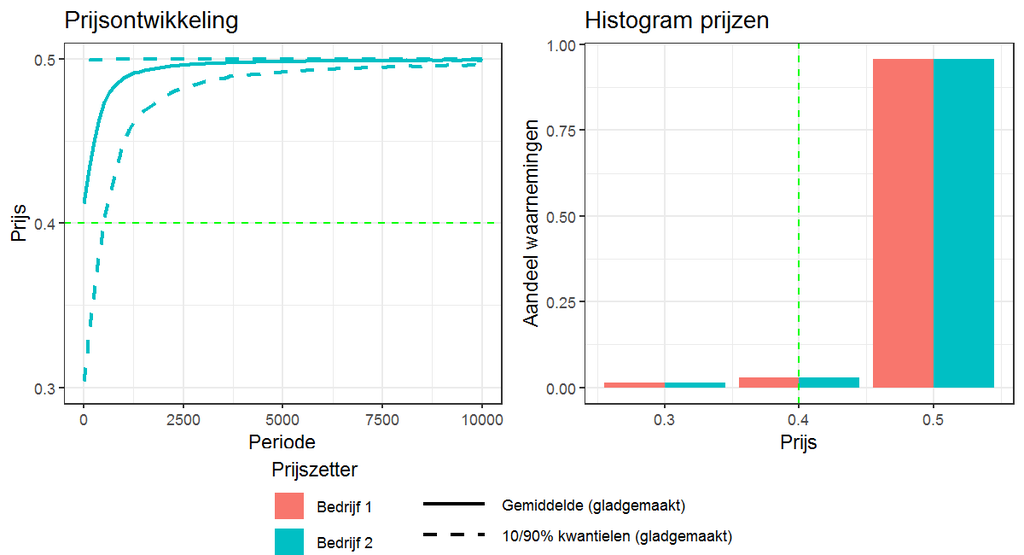

We will also run the simulations for a setting with three competitors.

In order to do so, we adjust the function carrying out the simulation.

```r
simulate_three <- function(P, alpha, beta, N, MC){
  #collect prices
  prices1 <- prices2 <- prices3 <- matrix(rep(NA, N*MC), N, MC)
  profits1 <- profits2 <- profits3 <- matrix(rep(NA, N*MC), N, MC)
  #loop over experiments
  for (mc in 1:MC){
    #sum of rewards
    sum_rewards1 <- sum_rewards2 <- sum_rewards3 <- matrix(rep(0, length(P)))
    #sum of squared rewards
    sum_rewards_sq1 <- sum_rewards_sq2 <- sum_rewards_sq3 <- matrix(rep(0, length(P)))
    #number of times each arm pulled
    Np1 <- Np2 <- Np3 <- matrix(rep(0, length(P)))
    #initialize
    pull1 <- sample(P, length(P))
    pull2 <- sample(P, length(P))
    pull3 <- sample(P, length(P))
    for (t in 1:length(P)){
      #calculate profit
      denom <- 1 + exp(alpha - beta * pull1[t]) + exp(alpha - beta * pull2[t]) + exp(alpha - beta * pull3[t])
      reward1 <- pull1[t]*exp(alpha - beta * pull1[t])/denom
      reward2 <- pull2[t]*exp(alpha - beta * pull2[t])/denom
      reward3 <- pull3[t]*exp(alpha - beta * pull3[t])/denom
      #sum of the profits per arm
      sum_rewards1[P == pull1[t]] <- sum_rewards1[P == pull1[t]] + reward1
      sum_rewards2[P == pull2[t]] <- sum_rewards2[P == pull2[t]] + reward2
      sum_rewards3[P == pull3[t]] <- sum_rewards3[P == pull3[t]] + reward3
      #sum of squared profits per arm
      sum_rewards_sq1[P == pull1[t]] <- sum_rewards_sq1[P == pull1[t]] + reward1^2
      sum_rewards_sq2[P == pull2[t]] <- sum_rewards_sq2[P == pull2[t]] + reward2^2
      sum_rewards_sq3[P == pull3[t]] <- sum_rewards_sq3[P == pull3[t]] + reward3^2
      #number of pulls per arm
      Np1[P == pull1[t]] <- Np1[P == pull1[t]] + 1
      Np2[P == pull2[t]] <- Np2[P == pull2[t]] + 1
      Np3[P == pull3[t]] <- Np3[P == pull3[t]] + 1
    }
    #loop over time periods
    for (t in 1:N){
      #choose arm with highest index value
      pull1 <- P[pull_arm(sum_rewards1, sum_rewards_sq1, Np1, t + length(P))]
      pull2 <- P[pull_arm(sum_rewards2, sum_rewards_sq2, Np2, t + length(P))]
      pull3 <- P[pull_arm(sum_rewards3, sum_rewards_sq3, Np3, t + length(P))]
      #calculate rewards
      denom <- 1 + exp(alpha - beta * pull1) + exp(alpha - beta * pull2) + exp(alpha - beta * pull3)
      reward1 <- pull1*exp(alpha - beta * pull1)/denom
      reward2 <- pull2*exp(alpha - beta * pull2)/denom
      reward3 <- pull3*exp(alpha - beta * pull3)/denom
      #sum of profits per arm
      sum_rewards1[P == pull1] <- sum_rewards1[P == pull1] + reward1
      sum_rewards2[P == pull2] <- sum_rewards2[P == pull2] + reward2
      sum_rewards3[P == pull3] <- sum_rewards3[P == pull3] + reward3
      #sum of squared profits per arm
      sum_rewards_sq1[P == pull1] <- sum_rewards_sq1[P == pull1] + reward1^2
      sum_rewards_sq2[P == pull2] <- sum_rewards_sq2[P == pull2] + reward2^2
      sum_rewards_sq3[P == pull3] <- sum_rewards_sq3[P == pull3] + reward3^2
      #number of pulls per arm
      Np1[P == pull1] <- Np1[P == pull1] + 1
      Np2[P == pull2] <- Np2[P == pull2] + 1
      Np3[P == pull3] <- Np3[P == pull3] + 1
      #collect prices
      prices1[t, mc] <- pull1
      prices2[t, mc] <- pull2
      prices3[t, mc] <- pull3
      #collect profits
      profits1[t, mc] <- reward1
      profits2[t, mc] <- reward2
      profits3[t, mc] <- reward3
    }
  }
  #save results in environment
  prices1 <<- prices1
  prices2 <<- prices2
  prices3 <<- prices3
  profits1 <<- profits1
  profits2 <<- profits2
  profits3 <<- profits3
}
```

We run 1000 experiments of 10000 periods.

```r
simulate_three(P = P, alpha = 5, beta = 5, N = 10000, MC = 1000)
```

We visualise the results in a way analogical the earlier simulations. Note that the Nash equilibrium is 0.3 with three competitors.

```r
#collect prices in data.frame
PP <- data.frame(price1 = c(prices1), price2 = c(prices2), price3 = c(prices3))
#long format
PP <- PP %>%
  gather(price1, price2, price3, key = "firm", value = "price")
#add iteration number
PP$iter <- rep(1:nrow(prices1), 3*ncol(prices1))
#calculate mean and quantiles
PPP <- PP %>% group_by(firm, iter) %>%
  summarize(mean = mean(price),
            upper = quantile(price, 0.9),
            lower = quantile(price, 0.1))
#label the statistic
PPP$type <- "Average"
PPP$type[(nrow(prices1)/2 + 1):nrow(prices1)] <- "10/90% quantiles"
#calculate shares of iterations per arm for the histogram
PP <- PP %>% group_by(firm, price) %>%
  summarize(share = length(iter)/(nrow(prices1)*ncol(prices1)))
#left panel
g1 <- ggplot() +
  #line for the mean
  geom_line(data = PPP, aes(x = iter, y = mean, color = firm)) +
  #loess smooth for the quantiles
  geom_smooth(data = PPP, aes(x = iter, y = upper, color = firm),
              method = "loess", span = 0.1, lty = 2, se = FALSE) +
  geom_smooth(data = PPP, aes(x = iter, y = lower, color = firm),
              method = "loess", span = 0.1, lty = 2, se = FALSE) +
  #invisible line for the legend (statistic)
  geom_line(data = PPP, aes(x = iter, y = lower, lty = type), color = NA) +
  #color palette
  scale_color_hue(name = "Prijszetter", labels = c("Bedrijf 1", "Bedrijf 2", "Bedrijf 3")) +
  #linetypes for legend
  scale_linetype_manual(name = "", values = c(1, 2),
                        labels = c("Gemiddelde", "10/90% kwantielen (gladgemaakt)")) +
  #tickmarks y-axis
  scale_y_continuous(
    breaks = seq(0.1, 1, 0.1),
    limits = c(0, 1)
  ) +
  #collusive price
  geom_hline(aes(yintercept = 0.9), color = "red", lty = 2) +
  #competitive price
  geom_hline(aes(yintercept = 0.3), color = "green", lty = 2) +
  #adjust legend
  guides(
    color = guide_legend(
      #squares
      override.aes = list(size = 7, shape = 15),
      order = 1
    ),
    linetype = guide_legend(
      override.aes = list(color = "black", size = 1),
      keywidth = 3
    )
  ) + theme_bw() +
  theme(
    legend.key = element_blank(),
    legend.position = "bottom", #below figure
    legend.box = "horizontal", #legenda's naast elkaar
    legend.direction = "vertical" #waarden onder elkaar
  ) +
  #labels
  labs(
    y = "Prijs",
    x = "Periode",
    title = "Prijsontwikkeling"
  )
#right panel (histogram)
g2 <- ggplot(PP) +
  #add bars
  geom_bar(aes(x = price, y = share, fill = firm), position = "dodge", stat = "identity") +
  #adjust tick-marks x-axis
  scale_x_continuous(
    breaks = seq(0.1, 1, 0.1),
    limits = c(0, 1)
  ) +
  #collusive price
  geom_vline(aes(xintercept = 0.9), color = "red", lty = 2) +
  #competitive price
  geom_vline(aes(xintercept = 0.3), color = "green", lty = 2) +
  #labels
  labs(
    y = "Aandeel waarnemingen",
    x = "Prijs",
    title = "Histogram prijzen"
  ) +
  #black and white theme
  theme_bw()
#construct left panel
tmp <- ggplot_gtable(ggplot_build(g1))
```

```r
#identify element containing legend
leg <- which(sapply(tmp$grobs, function(x) x$name) == "guide-box")
#extract legend
legend <- tmp$grobs[[leg]]
```

```r
png(filename="Fig_extra2.png", width=1200, height=700,
    pointsize = 12, res = 150)
#arrange left and right panel with common legend below
grid.arrange(arrangeGrob(g1 + theme(legend.position="none"),
                         g2 + theme(legend.position="none"), nrow = 1),
             legend, nrow=2, heights=c(10, 3))
dev.off()
```

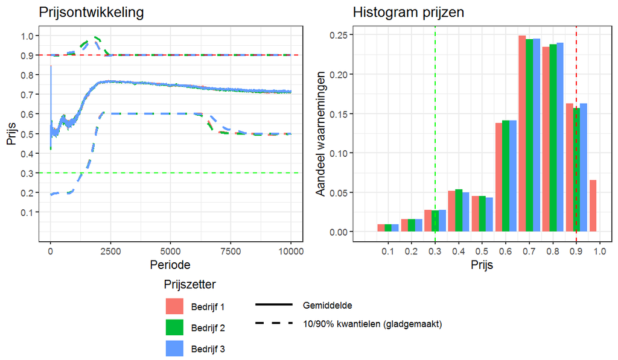